# Przekształcanie danych

Tomasz Olczyk

## Biblioteki na dziś

```r
library(tidyverse)
library(readxl)
library(here)
```

## Rozwiązanie zadania domowego:

```r
podatki <- read_excel(here( "podstawy",
  "Chapter14TablesFigures.xlsx"), # funkcja here wskazuje ścieżkę do pliku z poziomu katalogu roboczego do pliku Chapter14TablesFigures.xlsx w katalogy "podstawy
  sheet = "TS14.1", #wybieramy arkusz z pliku
  skip = 3 # usuwamy trzy pierwsze wiersze
  )
```

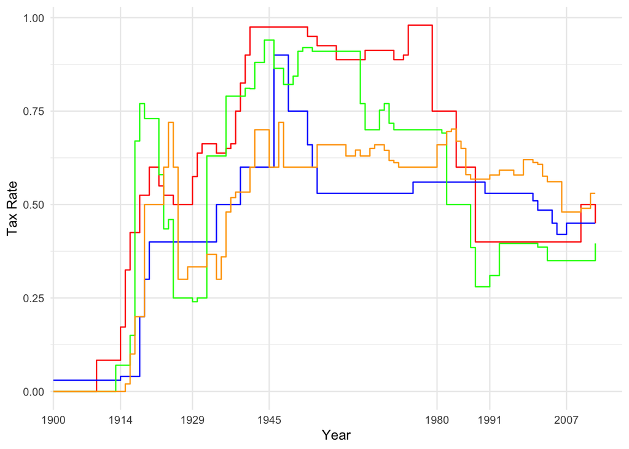

```r
ggplot(data = podatki) +
  geom_step(aes(x = `...1`, y = `U.K.`, group = 1), color = "red") +
  geom_step(aes(x = `...1`, y = `Germany`, group = 1), color = "blue") +
  geom_step(aes(x = `...1`, y = `U.S.`, group = 1), color = "green") +
  geom_step(aes(x = `...1`, y = `France`, group = 1), color = "orange") +
  # ponniższy wiersz ustawia punkty na osi x na wybrane lata:
 scale_x_discrete(breaks = c(1900, 1914, 1929, 1945, 1980, 1991, 2007)) +
  theme_minimal() +
  labs(y = "Tax Rate", x = "Year", color = "Country")
```

```r
# Przekształcenie danych do formatu długiego z użyciem gather
podatki_long <- podatki %>%
  select(`...1`, `U.S.`, `U.K.`, Germany, France) %>%
  gather(key = "Country", value = "Tax", -`...1`)
```

```r
# Przekształcenie danych do formatu długiego z użyciem pivot_longer
podatki_long <- podatki %>%
  select(`...1`, `U.S.`, `U.K.`, Germany, France) %>%
  pivot_longer(cols = -`...1`, names_to = "Country", values_to = "Tax")
```

W tym przypadku:

- cols = -…1 wskazuje, że kolumna …1 nie ma być przekształcana (tak jak wcześniej było to w gather).
- names_to = “Country” ustawia nazwę kolumny, która będzie zawierała nazwy krajów.
- values_to = “Tax” ustawia nazwę kolumny, która będzie zawierała wartości podatków.

Działa to bardzo podobnie do gather, ale pivot_longer jest nowszym i bardziej elastycznym podejściem.

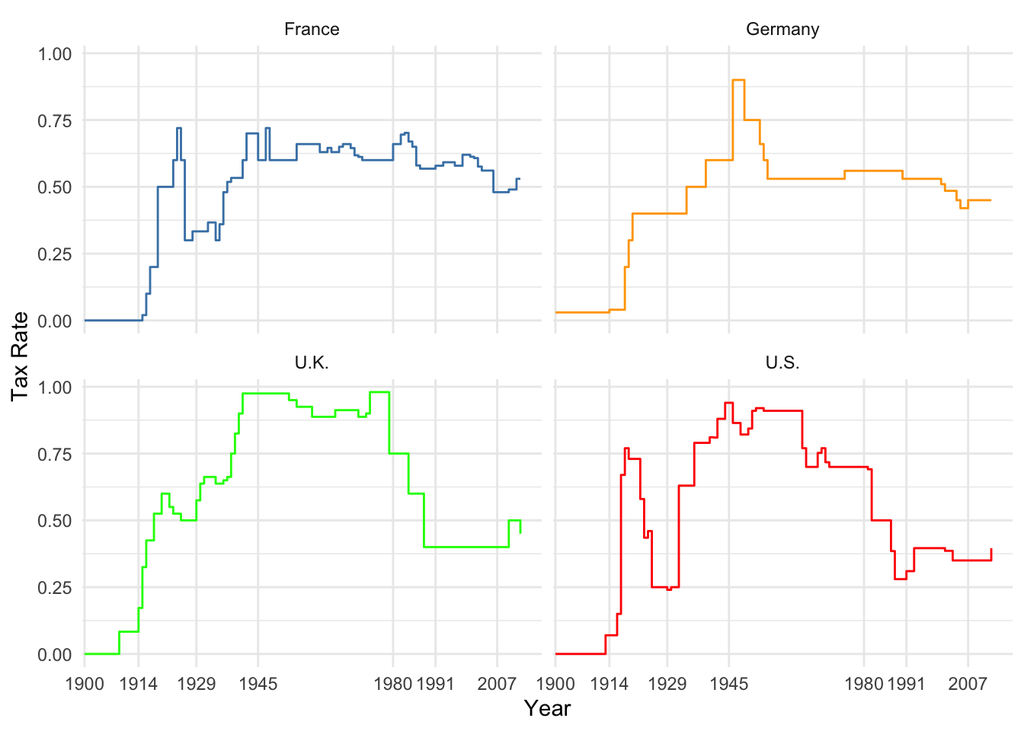

```r
# Tworzenie wykresu
ggplot(podatki_long, aes(x = `...1`, y = Tax, color = Country, group = Country)) +
  geom_step() +
  scale_color_manual(values = c("steelblue", "orange", "green", "red"), guide = "none") +
  #ylim(0, 1) +
  scale_x_discrete(breaks = c(1900, 1914, 1929, 1945, 1980, 1991, 2007)) +
  theme_minimal() +
  labs(y = "Tax Rate", x = "Year", color = "Country") +
  facet_wrap(~Country)
```

## Dane na dziś

```r
panteon <- read_csv("../podstawy/panteon_s.csv")
```

Te same dane używając here::here

```r
panteon <- read_csv(here("podstawy", "panteon_s.csv"))
```

Te same dane na githubie w razie kłopotów

```r
panteon <- read_csv("https://raw.githubusercontent.com/Tomasz-Olczyk/wizualizacjaR/main/podstawy/panteon_s.csv")
```

## Wybór kolumn (zmiennych) - select

Select wyodorębnia przydatny podzbiór danych, korzystając z operacji opartych na nazwach zmiennych, inaczej mówiąc selekcjonuje kolumny

```r
# glimpse pozwala zajrzeć do struktury ramki danych podobnie jak bazowa funkcja str
glimpse(panteon)
```

```
## Rows: 11,341
## Columns: 13
## $ name          <chr> "Abraham Lincoln", "Aristotle", "Ayn Rand", "Andre Agass…
## $ countryName   <chr> "UNITED STATES", "Greece", "Russia", "UNITED STATES", "U…
## $ countryCode3  <chr> "USA", "GRC", "RUS", "USA", "GBR", "RUS", "POL", "DEU", …
## $ LAT           <dbl> 37.57111, 40.33333, 59.95000, 36.12151, 51.18500, NA, 54…
## $ LON           <dbl> -85.738611, 23.500000, 30.300000, -115.173851, -0.610000…
## $ continentName <chr> "North America", "Europe", "Europe", "North America", "E…
## $ birthyear     <dbl> 1809, -384, 1905, 1970, 1894, 1932, 1788, 1879, -356, 18…
## $ gender        <chr> "Male", "Male", "Female", "Male", "Male", "Male", "Male"…
## $ industry      <chr> "GOVERNMENT", "PHILOSOPHY", "LANGUAGE", "INDIVIDUAL SPOR…
## $ domain        <chr> "INSTITUTIONS", "HUMANITIES", "HUMANITIES", "SPORTS", "H…
## $ L_star        <dbl> 5.801387, 11.914597, 3.175685, 6.242525, 6.219842, 9.298…
## $ HPI           <dbl> 27.93859, 31.99380, 24.32594, 20.92600, 25.99661, 25.244…
## $ AverageViews  <dbl> 504925.27, 370757.71, 258331.24, 162956.96, 149498.71, 7…
```

```r
dwie_kolumny <- select(panteon, name, gender)
```

```r
trzy_kolumny <- select(panteon, gender, name, domain)
```

### Inne przydatne funkcje selekcjonujące dla kolumn

starts_with() #zaczyna się od ciągu znaków ends_with() # kończy się na ciągu znaków contains() ##zawiera matches() ##zawiera

Minus stawiamy przed zmienną która ma zostać usunięta z ramki danych

```r
# mtcars należących do biblioteki datastes z bazowego R

glimpse(mtcars)
```

```
## Rows: 32
## Columns: 11
## $ mpg  <dbl> 21.0, 21.0, 22.8, 21.4, 18.7, 18.1, 14.3, 24.4, 22.8, 19.2, 17.8,…
## $ cyl  <dbl> 6, 6, 4, 6, 8, 6, 8, 4, 4, 6, 6, 8, 8, 8, 8, 8, 8, 4, 4, 4, 4, 8,…
## $ disp <dbl> 160.0, 160.0, 108.0, 258.0, 360.0, 225.0, 360.0, 146.7, 140.8, 16…
## $ hp   <dbl> 110, 110, 93, 110, 175, 105, 245, 62, 95, 123, 123, 180, 180, 180…
## $ drat <dbl> 3.90, 3.90, 3.85, 3.08, 3.15, 2.76, 3.21, 3.69, 3.92, 3.92, 3.92,…
## $ wt   <dbl> 2.620, 2.875, 2.320, 3.215, 3.440, 3.460, 3.570, 3.190, 3.150, 3.…
## $ qsec <dbl> 16.46, 17.02, 18.61, 19.44, 17.02, 20.22, 15.84, 20.00, 22.90, 18…
## $ vs   <dbl> 0, 0, 1, 1, 0, 1, 0, 1, 1, 1, 1, 0, 0, 0, 0, 0, 0, 1, 1, 1, 1, 0,…
## $ am   <dbl> 1, 1, 1, 0, 0, 0, 0, 0, 0, 0, 0, 0, 0, 0, 0, 0, 0, 1, 1, 1, 0, 0,…
## $ gear <dbl> 4, 4, 4, 3, 3, 3, 3, 4, 4, 4, 4, 3, 3, 3, 3, 3, 3, 4, 4, 4, 3, 3,…
## $ carb <dbl> 4, 4, 1, 1, 2, 1, 4, 2, 2, 4, 4, 3, 3, 3, 4, 4, 4, 1, 2, 1, 1, 2,…
```

```r
mtcars_bez_kolumn_zaczynających_się_od_d <-select(mtcars, -starts_with("d"))
```

```r
od_c <- panteon %>%
  select(starts_with("c"))
```

```r
bez_c <- panteon %>%
  select(-starts_with("c"))
```

```r
names(mtcars_bez_kolumn_zaczynających_się_od_d) #funkcja names() zwraca nazwy kolumn(zmiennych) w ramce danych
```

```
## [1] "mpg"  "cyl"  "hp"   "wt"   "qsec" "vs"   "am"   "gear" "carb"
```

### Funkcje pomocnicze funkcji select

starts_with(“abc”) - wybiera nazwy rozpoczynające się od „abc”

ends_with(“xyz”-wybiera nazwy kończące się na „xyz”

contains(“ijk”) _ wybiera nazwy zawierające „ijk”.

matches(“(.)\1”) # wybiera zmienne pasujące do wyrażenia regularnego

subset_mtcars <- select(mtcars, matches(“pg|gea”))

```r
# wybiera kolumny w których jest ciąg znaków en lub cou

en_lub_cou <- panteon  %>%
  select(matches("en|cou"))
```

### Zmiana nazw kolumn: rename

Selekcjonując kolumny możemy od razu zmienić ich nazwy

Schemat: select(ramka_danych, nowa_nazwa = stara_nazwa)

```r
wzrost_waga <- select(starwars, wzrost = height, masa = mass)
```

Do bezpośedniej zmiany służy funcja rename. Schemat zmiany nazwy jak w przypadku select.

rename() zachowuje wszystkie zmienne, które nie zostały podane jawnie

```r
starwars_pl <- rename(starwars,
                      wzrost = height,
                      masa = mass) # drugi argument jest nową nazwą kolumny/zmiennej
```

```r
panteon_pl <- panteon %>%
  rename(płeć = gender)
```

## Podzbiory obserwacji: funkcja filter()

Funkcja filter umożliwia tworzenie podzbioru obserwacji na podstawie ich wartości

Wybieramy wszystkie postacie z Gwiezdnych Wojen o wzroście powyżej 200 cm

```r
View(starwars)
```

```r
glimpse(starwars)
```

```
## Rows: 87
## Columns: 14
## $ name       <chr> "Luke Skywalker", "C-3PO", "R2-D2", "Darth Vader", "Leia Or…
## $ height     <int> 172, 167, 96, 202, 150, 178, 165, 97, 183, 182, 188, 180, 2…
## $ mass       <dbl> 77.0, 75.0, 32.0, 136.0, 49.0, 120.0, 75.0, 32.0, 84.0, 77.…
## $ hair_color <chr> "blond", NA, NA, "none", "brown", "brown, grey", "brown", N…
## $ skin_color <chr> "fair", "gold", "white, blue", "white", "light", "light", "…
## $ eye_color  <chr> "blue", "yellow", "red", "yellow", "brown", "blue", "blue",…
## $ birth_year <dbl> 19.0, 112.0, 33.0, 41.9, 19.0, 52.0, 47.0, NA, 24.0, 57.0, …
## $ sex        <chr> "male", "none", "none", "male", "female", "male", "female",…
## $ gender     <chr> "masculine", "masculine", "masculine", "masculine", "femini…
## $ homeworld  <chr> "Tatooine", "Tatooine", "Naboo", "Tatooine", "Alderaan", "T…
## $ species    <chr> "Human", "Droid", "Droid", "Human", "Human", "Human", "Huma…
## $ films      <list> <"The Empire Strikes Back", "Revenge of the Sith", "Return…
## $ vehicles   <list> <"Snowspeeder", "Imperial Speeder Bike">, <>, <>, <>, "Imp…
## $ starships  <list> <"X-wing", "Imperial shuttle">, <>, <>, "TIE Advanced x1",…
```

```r
dwumetrowcy_GW <- filter(starwars, height >= 200)
```

Zadanie odfiltrujmy postacie o wzroście powyżej 150 cm i o masie poniżej średniej

```r
library(tidyverse)
```

```r
mean(starwars$mass, na.rm = TRUE)
```

```
## [1] 97.31186
```

```r
tacy <- filter(starwars, height > 150 &
           mass < mean(starwars$mass, na.rm = TRUE)
                 )
```

Funkcje z pakietu dplyr nigdy nie modyfikują danych wejściowych dlatego trzeba je zapisać do nowej ramki danych.

```r
kobiety_pow_śr <- filter(panteon, gender == "Female", AverageViews > mean(AverageViews, na.rm = TRUE))
```

### użycie operatora %in%

%in% stosujemy kiedy mamy zbiór warunków filtrujących

x %in% y - zostanie wybrany każdy wiersz, w którym x jest jedną z wartości w y

Wybierzmy osoby ze zbioru Panteon urodzone w czasie wojen światowych

```r
urodzeni_w_czasie_wś <- filter(panteon, birthyear %in% c(1914:1918, 1939:1945))
```

Szybkie podsumowanie funkcją table:

```r
tabela <- table(urodzeni_w_czasie_wś$birthyear)
```

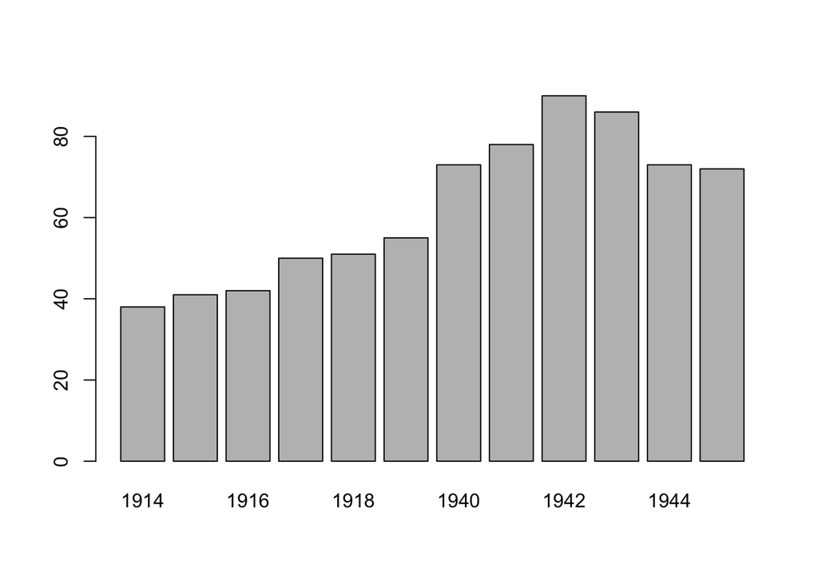

```r
barplot(table(urodzeni_w_czasie_wś$birthyear))
```

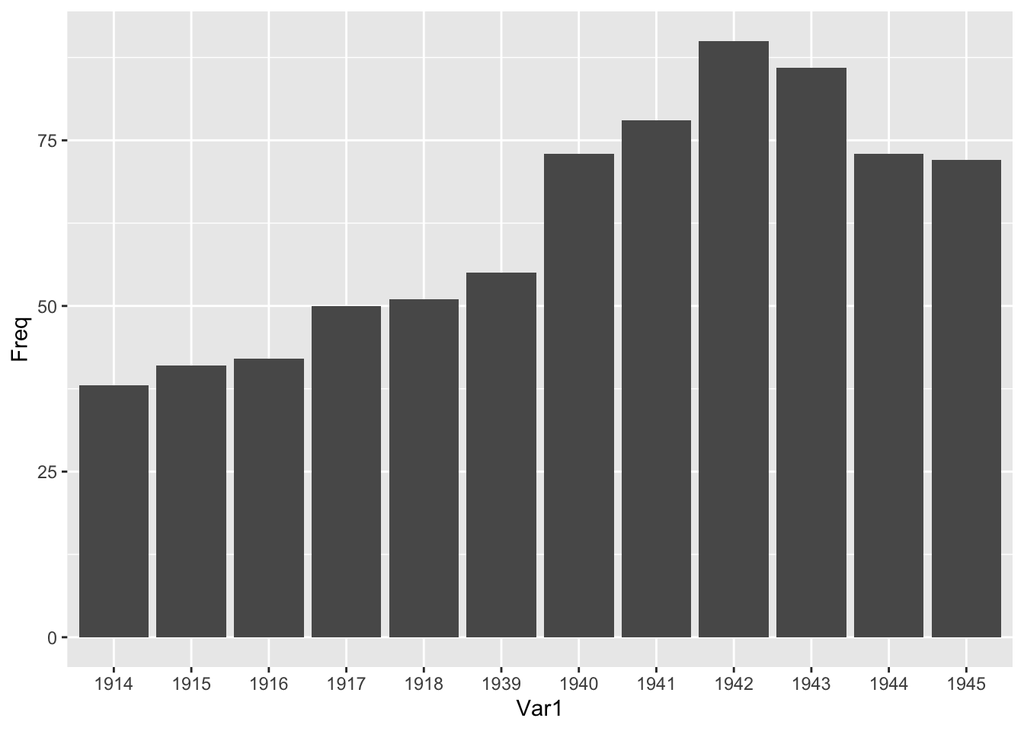

```r
ggplot(data = data.frame(table(urodzeni_w_czasie_wś$birthyear))) +
         geom_col(aes(x = Var1, y = Freq))
```

### Zadanie stwórzmy ramkę danych kobiet z Polski ze zbioru Panteon - użyjmy zmiennej countryCode3 wartość POL

```r
kobiety_z_pol <- filter(panteon, countryCode3 == "POL", gender == "Female")
```

gender

### funkcja between jako część filtrowania

```r
?between() # dla wektora liczb
```

```r
boomerzy <- filter(panteon, between(birthyear, 1945, 1960))
```

### filtrowanie wierszy na podstawie ciągów znaków

#### Jak wyszukać te postacie z Gwiezdnych Wojen, które mają częściowo zieloną skórę?

```r
zieloni <- starwars %>%
  filter(skin_color == "green")
```

```r
bez_zielonych <- starwars %>%
  filter(skin_color != "green")
```

```r
bez_zielonych_t <- starwars %>%
  filter(!skin_color == "green")
```

Filtrowanie przez ciagi znaków.

```r
?grepl
```

```r
?str_detect()
```

```r
Green_and_grepl <-  filter(starwars, grepl("green", skin_color))
```

```r
Green_and_grepl_str <-  filter(starwars, str_detect(skin_color, "green"))
```

```r
?stringr::str_detect()
```

```r
Green_and_stringr <-  filter(starwars,
                             str_detect(skin_color, "green"))
```

```r
?contains
```

```
## Help on topic 'contains' was found in the following packages:
##
##   Package               Library
##   tidyselect            /Library/Frameworks/R.framework/Versions/4.2/Resources/library
##   vroom                 /Library/Frameworks/R.framework/Versions/4.2/Resources/library
##   dplyr                 /Library/Frameworks/R.framework/Versions/4.2/Resources/library
##   tidyr                 /Library/Frameworks/R.framework/Versions/4.2/Resources/library
##
##
## Using the first match ...
```

```r
?str_detect
```

#### Zadanie Marie z XIX w.

Wybierzmy ze zbioru panteon osoby płci żeńskiej o imieniu Maria lub Marie urodzone w XIX wieku.

```r
Kobiety_Maria <- filter(panteon, gender == 'Female', (str_detect(name, "Mari")), between(birthyear, 1800, 1900))
```

```r
Ann <-  filter(panteon, str_detect(name, "Ann"), between(birthyear, 1801, 1900),  gender == 'Female')
```

## Potoki

```r
kobiety_po1900 <- panteon %>%
  filter(gender == "Female" & birthyear >= 1900)
```

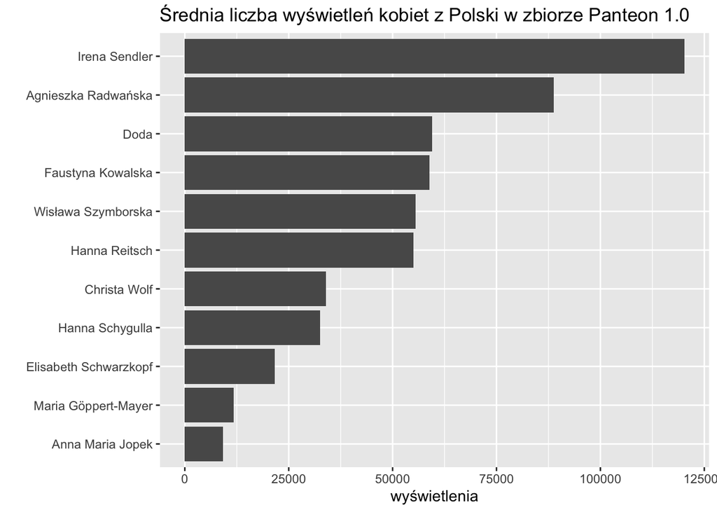

```r
panteon %>%
  filter(gender == "Female" & birthyear >= 1900 & countryCode3 == "POL") %>%
  ggplot() +
  geom_col(aes(x = reorder(name, AverageViews), y = AverageViews)) +
  coord_flip() +
  labs(title = "Średnia liczba wyświetleń kobiet z Polski w zbiorze Panteon 1.0") +
  xlab("") +
  ylab("wyświetlenia")
```

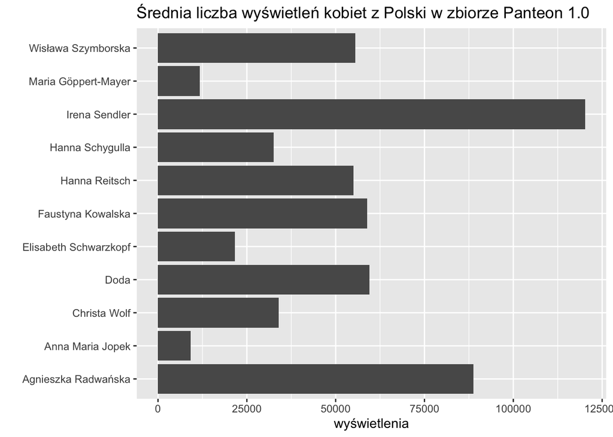

```r
panteon %>%
  filter(gender == "Female" & birthyear >= 1900 & countryCode3 == "POL") %>%
  ggplot() +
  geom_col(aes(x = name, y = AverageViews)) +
  coord_flip() +
  labs(title = "Średnia liczba wyświetleń kobiet z Polski w zbiorze Panteon 1.0") +
  xlab("") +
  ylab("wyświetlenia")
```

[output not shown]

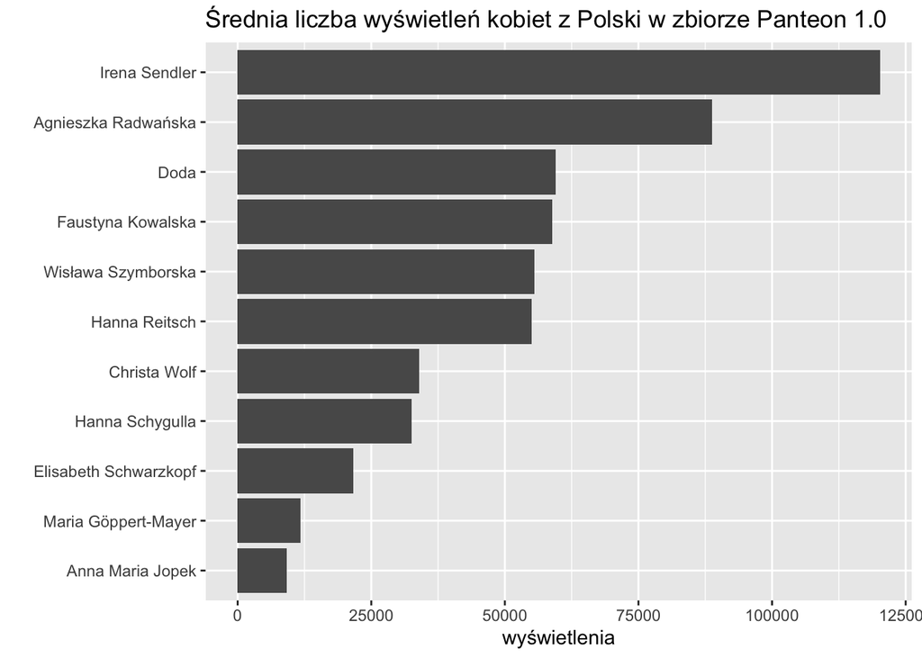

```r
panteon %>%
  filter(gender == "Female" & birthyear >= 1900 & countryCode3 == "POL") %>%
  ggplot() +
  geom_col(aes(x = reorder(name, AverageViews), y = AverageViews)) +
  coord_flip() +
  labs(title = "Średnia liczba wyświetleń kobiet z Polski w zbiorze Panteon 1.0") +
  xlab("") +
  ylab("wyświetlenia")
```

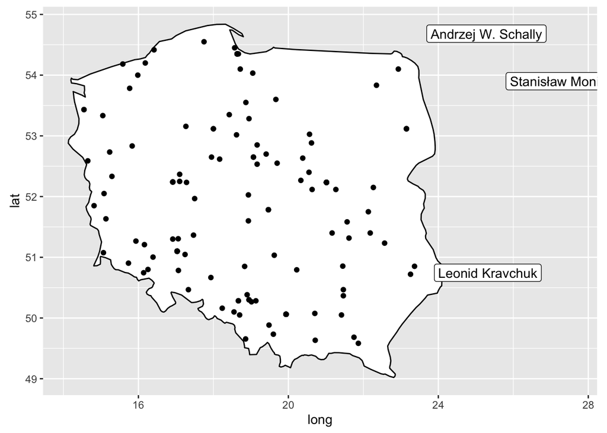

```r
ggplot(map_data("world", region = 'Poland'),
        aes(long, lat, group = group)) +
  geom_polygon(fill = "white",
               color = "black") +
  geom_point(data = panteon %>% filter(countryCode3 == "POL"), aes(x = LON, y = LAT, group = name)) +
  geom_label(data = panteon %>% filter(countryCode3 == "POL",
                                       LON > 25
                                       )
             , aes(x = LON, y = LAT, group = name, label = name)) +
coord_quickmap()
```

## Grupowanie obserwacji i podsumowania, funkcje group_by i summarise

## Podsumowanie - summarise() summarize() - podsumowania

funkcja zwija ramkę danych do jednego wiersza

### group_by i summarize

Summarize występuje najczęściej w towarzystwie group_by, która pozwala porównywać grupy inaczej mówiąc tworzyć zgrupowane podsumowania

Np. gdybyśmy chcieli zsumować sławy ze zbioru panteon 1.0 według kontynentów

```r
panteon %>%
  group_by(continentName) %>%
  summarise(sławni = n()) # funkcja n() sumuje liczbę obserwacji
```

```
## # A tibble: 8 × 2
##   continentName sławni
##   <chr>          <int>
## 1 Africa           419
## 2 Asia            1188
## 3 Europe          6368
## 4 North America   2439
## 5 Oceania          123
## 6 South America    366
## 7 Unknown          408
## 8 <NA>              30
```

Możemy grupować na wielu zmiennych

```r
panteon %>%
  group_by(continentName, gender) %>%
  summarise(sławni = n())
```

```
## # A tibble: 16 × 3
## # Groups:   continentName [8]
##    continentName gender sławni
##    <chr>         <chr>   <int>
##  1 Africa        Female     38
##  2 Africa        Male      381
##  3 Asia          Female    137
##  4 Asia          Male     1051
##  5 Europe        Female    655
##  6 Europe        Male     5713
##  7 North America Female    586
##  8 North America Male     1853
##  9 Oceania       Female     35
## 10 Oceania       Male       88
## 11 South America Female     31
## 12 South America Male      335
## 13 Unknown       Female     12
## 14 Unknown       Male      396
## 15 <NA>          Female      1
## 16 <NA>          Male       29
```

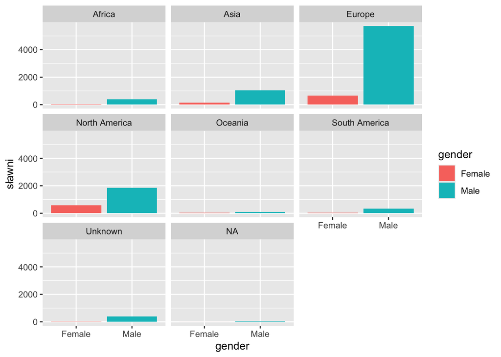

```r
panteon %>%
  group_by(continentName, gender) %>%
  summarise(sławni = n()) %>%
  ggplot() +
  geom_col(aes(x = gender,
               y = sławni,
               fill = gender)) +
  facet_wrap(~continentName)
```

Summarsie może dotyczyć wielu typów podsumowań np. średnich

```r
ramka <- panteon %>%
  group_by(continentName, gender) %>%
  summarise(średnie_wyś = mean(AverageViews, na.rm = TRUE))
```

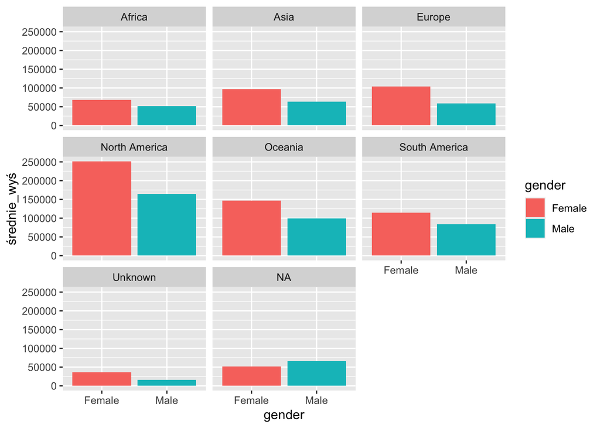

```r
ggplot(ramka, aes(x = gender,
                  y = średnie_wyś,
                  fill = gender)) +
  geom_col() +
  facet_wrap(~continentName)
```

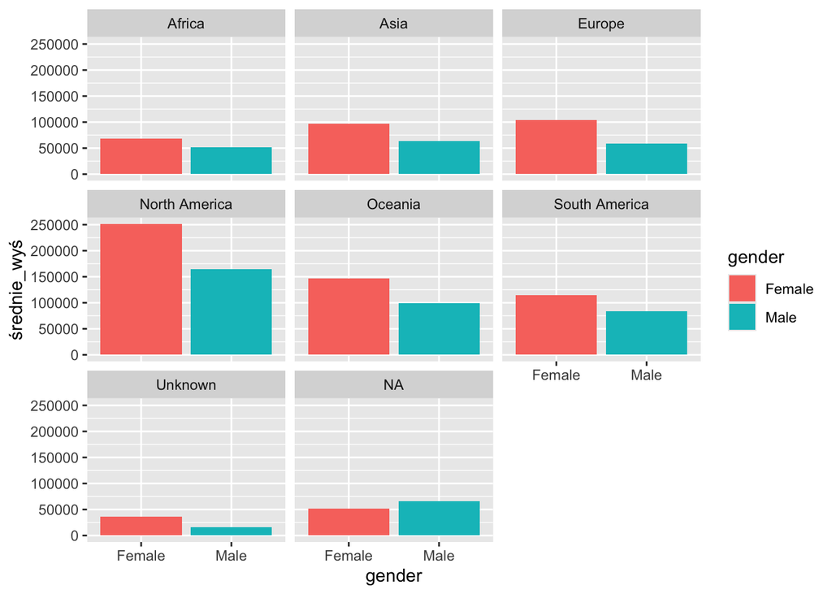

```r
panteon %>%
  group_by(continentName, gender) %>%
  summarise(średnie_wyś = mean(AverageViews, na.rm = TRUE)) %>%
  ggplot(aes(x = gender, y = średnie_wyś, fill = gender)) +
  geom_col() +
  facet_wrap(~continentName)
```

## Wartości brakujące

```r
?is.na()
```

```r
is.na(starwars)
```

```
##        name height  mass hair_color skin_color eye_color birth_year   sex
##  [1,] FALSE  FALSE FALSE      FALSE      FALSE     FALSE      FALSE FALSE
##  [2,] FALSE  FALSE FALSE       TRUE      FALSE     FALSE      FALSE FALSE
##  [3,] FALSE  FALSE FALSE       TRUE      FALSE     FALSE      FALSE FALSE
##  [4,] FALSE  FALSE FALSE      FALSE      FALSE     FALSE      FALSE FALSE
##  [5,] FALSE  FALSE FALSE      FALSE      FALSE     FALSE      FALSE FALSE
##  [6,] FALSE  FALSE FALSE      FALSE      FALSE     FALSE      FALSE FALSE
##  [7,] FALSE  FALSE FALSE      FALSE      FALSE     FALSE      FALSE FALSE
##  [8,] FALSE  FALSE FALSE       TRUE      FALSE     FALSE       TRUE FALSE
##  [9,] FALSE  FALSE FALSE      FALSE      FALSE     FALSE      FALSE FALSE
## [10,] FALSE  FALSE FALSE      FALSE      FALSE     FALSE      FALSE FALSE
## [11,] FALSE  FALSE FALSE      FALSE      FALSE     FALSE      FALSE FALSE
## [12,] FALSE  FALSE  TRUE      FALSE      FALSE     FALSE      FALSE FALSE
## [13,] FALSE  FALSE FALSE      FALSE      FALSE     FALSE      FALSE FALSE
## [14,] FALSE  FALSE FALSE      FALSE      FALSE     FALSE      FALSE FALSE
```

[output cut: 161 more lines]

### Odfiltrowywaanie wartości brakujących

różnica między is.na a drop.na

```r
waga_GW_bez_brakujacych  <- filter(starwars,
                                   !is.na(mass))
```

```r
wzrost_GW_bez_brakujących <- filter(starwars,
                                   !is.na(height))
```

```r
?drop_na()
```

```r
starwars_drop_na <- drop_na(starwars)
```

```r
?na.omit
```

```r
starwars_na.omit <- na.omit(starwars)
```

na.omit, i drop_na Usuwają z ramki danych wszystkie obserwacje zawierające wartości brakujące.

```r
GW_drop_na <- starwars %>%
  drop_na()
```

```r
GW_na.omit <- na.omit(starwars)
```

### Imputowanie

Dygresja na temat impitowania: Prosty przykład imputowania.

```r
library(mice)
imputed_data <- mice(panteon, method = 'pmm', m =1)  # m = liczba imputowanych zestawów
panteon_imputed <- complete(imputed_data)
```

```r
test <- panteon_imputed %>%
  drop_na()
```

```r
test1 <- panteon %>%
  drop_na()
```

## Arrange

```r
arrange(starwars, height) #
```

```
## # A tibble: 87 × 14
##    name     height  mass hair_color skin_color eye_color birth_year sex   gender
##    <chr>     <int> <dbl> <chr>      <chr>      <chr>          <dbl> <chr> <chr>
##  1 Yoda         66    17 white      green      brown            896 male  mascu…
##  2 Ratts T…     79    15 none       grey, blue unknown           NA male  mascu…
##  3 Wicket …     88    20 brown      brown      brown              8 male  mascu…
##  4 Dud Bolt     94    45 none       blue, grey yellow            NA male  mascu…
##  5 R2-D2        96    32 <NA>       white, bl… red               33 none  mascu…
##  6 R4-P17       96    NA none       silver, r… red, blue         NA none  femin…
##  7 R5-D4        97    32 <NA>       white, red red               NA none  mascu…
##  8 Sebulba     112    40 none       grey, red  orange            NA male  mascu…
##  9 Gasgano     122    NA none       white, bl… black             NA male  mascu…
## 10 Watto       137    NA black      blue, grey yellow            NA male  mascu…
## # ℹ 77 more rows
## # ℹ 5 more variables: homeworld <chr>, species <chr>, films <list>,
## #   vehicles <list>, starships <list>
```

```r
arrange(starwars, desc(height))
```

```
## # A tibble: 87 × 14
##    name     height  mass hair_color skin_color eye_color birth_year sex   gender
##    <chr>     <int> <dbl> <chr>      <chr>      <chr>          <dbl> <chr> <chr>
##  1 Yarael …    264    NA none       white      yellow          NA   male  mascu…
##  2 Tarfful     234   136 brown      brown      blue            NA   male  mascu…
##  3 Lama Su     229    88 none       grey       black           NA   male  mascu…
##  4 Chewbac…    228   112 brown      unknown    blue           200   male  mascu…
##  5 Roos Ta…    224    82 none       grey       orange          NA   male  mascu…
##  6 Grievous    216   159 none       brown, wh… green, y…       NA   male  mascu…
##  7 Taun We     213    NA none       grey       black           NA   fema… femin…
##  8 Rugor N…    206    NA none       green      orange          NA   male  mascu…
##  9 Tion Me…    206    80 none       grey       black           NA   male  mascu…
## 10 Darth V…    202   136 none       white      yellow          41.9 male  mascu…
## # ℹ 77 more rows
## # ℹ 5 more variables: homeworld <chr>, species <chr>, films <list>,
## #   vehicles <list>, starships <list>
```

```r
wg_masy <- arrange(starwars, desc(mass))
```

```r
wg_wzrostu <-  arrange(starwars, height)
```

### Tworzenie nowych zmiennych (kolumn): mutate()

Dodawanie nowych kolumn, powstałych w wyniku wykonania funkcji na już istniejących kolumnach - operacje różnego typu - zawsze dodaje nowe kolumny na końcu

Zmieniamy kolumnę z nazwami krajów w zbiorze panteon:

```r
panteon <- panteon %>%
  mutate(kraj = toupper(countryName))
```

Zmieniamy wzrost na cale i masę a funty w zbiorze starwars.

```r
starwars <- starwars %>%
  mutate(wfuntach = mass/2.204,
         wcalach = height/2.5)
```

## Rangowania

```r
starwars <- starwars %>%
  mutate(rangi_waga = min_rank(mass),
         wiersz = row_number())
```

```r
rząd <- starwars %>%
  mutate(rząd = row_number())
```

[figure not shown]

```r
wg_masy %>%
  slice_max(n =5, order_by = mass) %>%
  ggplot() +
  geom_col(aes(x = reorder(name, mass), y = mass)) +
  coord_flip()
```

```r
masa_rangowanie_procent  <- starwars %>%
  mutate(rangi = percent_rank(mass))
```

```r
numer_wiersza <- starwars %>%
  mutate(numer_wiersza = row_number(mass))
```

## sample - pobieranie próby

```r
?slice_sample()
```

```r
najwyżsi <- starwars %>%
  slice_max(n=10, height)
```

```r
losowo <- slice_sample(starwars, n = 10)
```

```r
losowo <- slice_sample(starwars, n= 10)
```

```r
GW_random_ten <- starwars %>%
  slice_sample(n= 10)
```

```r
tail_5_GW_masa <- starwars %>%
  slice_min(n = 5, mass) #według jakiej zmiennj ma być dobrana próbka
```

## Złączenia

stwórzmy dwie ramki danych

```r
x <- starwars %>%
  slice_max(n = 7, height) %>%
  select(name, height)
```

```r
x <- slice_max(starwars,
               n= 7,
               height) %>%
  select(name, height)
```

```r
y <- starwars %>%
  filter(!is.na(mass)) %>%
  slice_max(n= 7, height) %>%
  select(name, height)
```

```r
pełne <- full_join(x, y)
lewe <- left_join(x,y)
prawe <- right_join(x,y)
wewn <- inner_join(x,y)
złączona <-  inner_join(x, y)
 wzrost_zł <- inner_join(x, y, by = "height")
```

### Typy złączeń

inner_join(x,y) dopasowuje te pary obserwacji, których klucze są jednakowe

left_join(x, y) zachowuje wszystkie obserwacje z tabeli x

right_join(x, y) # zachowuje wszystkie obserwacje z tabeli y

right_join(y, x) # zachowuje wszystkie obserwacje z tabeli y

full_join(x,y) # zachowuje wszystkie obserwacje z obu tabel

```r
pełne <- full_join(x, y)
prawe <- right_join(x, y)
```

### Złączenie filtrujące

```r
semi <- semi_join(x, y)
anti <- anti_join(x, y)
```

semi_join(x, y) # zachowuje wszystkie obserwacje w tabeli x, dla których istnieje dopasowanie w tabeli y

anti_join(x, y) # opuszcza wszystkie obserwacje w tabeli x, dla których istnieje dopasowanie w tabeli y

```r
anti <- anti_join(x,y)
sem <- semi_join(x,y)
```

### Analogiczne operacje na zbiorach z użycue funkcji bazowego R

intersect() # Zwraca tylko obserwacje znajdujące się zarówno w x, jak i w y.

union() # Zwraca unikatowe obserwacje z x i y.

setdiff(x, y) # Zwraca obserwacje znajdujące się w x, ale nie w y.

### Zadanie domowe

Ze zbioru Panteon wybierzmy kraje należace niegdyś do Rzeczypospolitej Obojga Narodów (Białoruś, Litwa, Polska, Ukraina), wybierzmy osoby urodzone pomiędzy Unią Lubelską a pierwszym rozbiorem, stwórzmy wykres panelowy porównujący liczbę sławnych kobiet i mężczyzn w każdym z tych krajów. Dodajmy tytuł, podtytuł, informację o źródle, sformatujmy wykres według wybranego biblioteki ggthemes.

### Co przed następnymi zajęciami?

Rozdział 22 Grafika dla komunikacji z wykorzystaniem ggplot2: Wickham, H., & Grolemund, G. (2020). Język R: Kompletny zestaw narzędzi dla analityków danych (J. Zatorska, Tłum.). Wydawnictwo Helion.

[prawie to samo online po angielsku](https://r4ds.hadley.nz/communication)